# The second part

We have 304 valid agents from the contracted_agents file and 881 unique logins in the sales_jan_jul file. Let's start with a general overview of the sales data — a summary table of sales and leads. Then we’ll move on to analyzing agents for whom we have information.

|  | Total profit | Sales Count | Leads Taken |
| --- | --- | --- | --- |
| mean | 6.152326 | 1.223072 | 212.995421 |
| std | 8.344309 | 0.558375 | 247.285363 |
| min | -5.569839 | 1.000000 | 1.000000 |
| 25% | 1.418392 | 1.000000 | 33.000000 |
| 50% | 3.782100 | 1.000000 | 134.000000 |
| 75% | 7.674975 | 1.000000 | 316.000000 |
| max | 140.127120 | 15.000000 | 4652.000000 |

In the table above, Leads Taken reflects the number of leads received on average by an agent per month (based on the assigned_leads file). On the other hand, the metrics Total profit and Sales Count are daily averages per agent — calculated only for the days when the agent made at least one sale. Days without any sales are not considered.

If we take into account all days in the sales_jan_jul table from 01.01.2024 to 31.07.2024, including days with no sales, then **on average, each agent makes about 0.05 sales per day and earns $0.26 in profit per day**.

You can also see that the median (50th percentile) and the maximum in the Leads Taken column differ significantly. This indicates an uneven distribution of leads. And there is a **clear outlier — the row "va380, 2024-05" with a "Leads Taken" value of 4652**, with the next highest values being 2957 and 2499. After that, the values decline more gradually.

Let’s highlight the top 10 agents by number of sales and the bottom 10 with the lowest results.

Top 10

| Login | Sales Count |
| --- | --- |
| am212 | 103 |
| vk659 | 99 |
| ap168 | 81 |
| np100 | 81 |
| mb151 | 80 |
| em142 | 80 |
| sm1123 | 74 |
| ak124 | 72 |
| gg100 | 71 |
| sa159 | 71 |

Bottom 10

| Login | Sales Count |
| --- | --- |
| mm1730 | 1 |
| nb621 | 1 |
| my277 | 1 |
| mv339 | 1 |
| ms3181 | 1 |
| ms1898 | 1 |
| mr1304 | 1 |
| mp321 | 1 |
| mp100 | 1 |
| mk1737 | 1 |

Below is a table showing the top 10 agents who received the most leads and the bottom 10 with the fewest received leads.

Top 10

| Login | Leads Taken |
| --- | --- |
| vr209 | 11004 |
| va380 | 8301 |
| ak1020 | 6887 |
| hm339 | 6297 |
| mg524 | 6071 |
| ss5550 | 5772 |
| jp246 | 5532 |
| bo117 | 5202 |
| al448 | 5029 |
| dk593 | 4884 |

Bottom 10

| Login | Leads Taken |
| --- | --- |
| sm2315 | 1 |
| ak1762 | 1 |
| kr171 | 1 |
| mb627 | 1 |
| ja500 | 1 |
| ss5739 | 1 |
| sk3877 | 1 |
| pn306 | 1 |
| mb890 | 1 |
| hs952 | 1 |

It’s also worth noting that **none of the top 10 agents by sales appear in the top 10 by received leads**. The first overlap is the 9th-ranked sales agent “gg100,” who ranks 162nd in terms of received leads out of 2436 agents who received at least some leads.

In the sales table, there are 13 logins that do not appear in the lead assignment table. Out of 881 logins in sales_jan_jul, only 868 are present in assigned_leads. Presumably, some agents received leads before the first date in assigned_leads, or there is a data error. Nevertheless, if we calculate the number of leads required for a single sale using this data, **on average, 133 leads are needed to make one sale, which typically generates $5 in profit (Total profit)**.

Let’s look at the overall distribution of sales — how many agents made a certain number of sales.

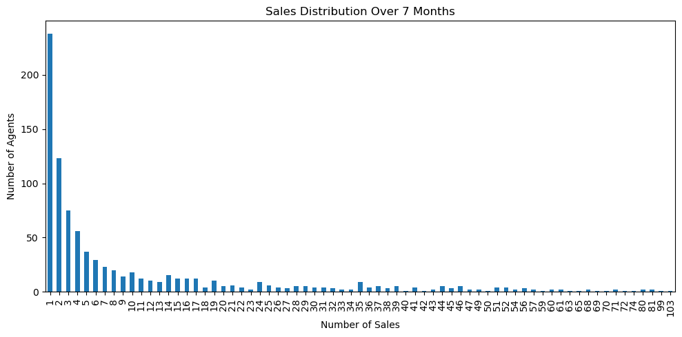

As shown in the chart, the vast majority of agents — **approximately 56% — made no more than 4 sales over the 7-month period**. This may indicate that a large portion of agents stopped working shortly after starting.

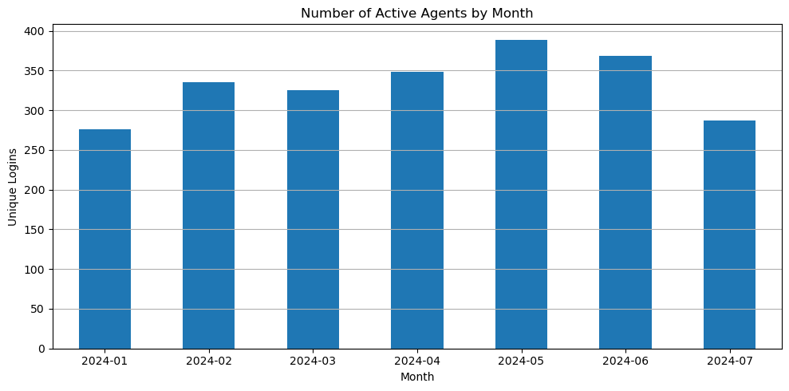

Until May, there was a relatively positive trend in the number of active agents, but from May to July, the number began to decline, especially noticeably from June to July.

It is likely that new employees tend to quit early, possibly due to the low number of leads they receive in the beginning. Let’s test this hypothesis by analyzing new agents from contracted_agents who signed contracts just before the sales_jan_jul period. We’ll examine how the average number of received leads changes based on months of employment.

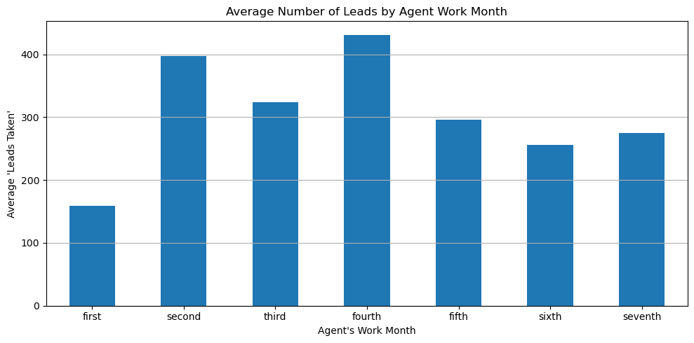

According to the data, **in their first month, agents receive on average 2 times fewer leads than in the following months**. This likely explains why nearly half of all agents quit after the first month. Below is a table showing how many months agents from contracted_agents stayed active.

| Month Number | 1 | 2 | 3 | 4 | 5 | 6 | 7 |
| --- | --- | --- | --- | --- | --- | --- | --- |
| count | 212 | 108 | 73 | 38 | 33 | 28 | 19 |

Out of 304 valid agents in contracted_agents, only 212 received leads to work with, according to the assigned_leads data. This means that about 30% of agents never started working despite signing a contract. All contracts were signed in December 2023 or January 2024, while the sales period covers the first 7 months of 2024. It is likely that these agents either were not given leads or refused to work after signing the contract. Let’s try to determine if there is any correlation between this and the time between application submission and contract signing (based on contracted_agents data).

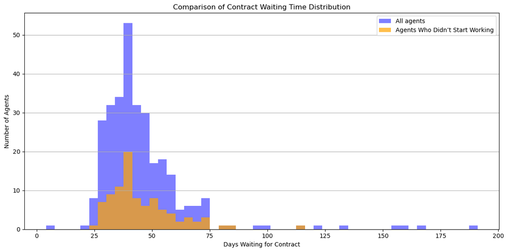

Based on the distribution, there is no clear correlation: **the number of days between application and contract signing does not affect whether the agent received leads. There is also no dependency on ad source or education level — agents without leads are present across all groups**.

Let’s move on to a general analysis of the agent data.

| Education Level | Bachelor | College | Masters | Professional | School | Doctorate |
| --- | --- | --- | --- | --- | --- | --- |
| count | 135 | 71 | 45 | 32 | 11 | 2 |

| Country of Residence | India | Nigeria | Pakistan | Uzbekistan | Moldova |
| --- | --- | --- | --- | --- | --- |
| count | 291 | 6 | 3 | 3 | 1 |

| Source of Advertisement | facebook | Google | linkedin | HRM | DPTR | instagram_bio | indeed | fecebook_bot |
| --- | --- | --- | --- | --- | --- | --- | --- | --- |
| count | 151 | 126 | 9 | 8 | 4 | 2 | 2 | 2 |

We’ll review the summary data by agent and analyze how the average number of sales per person over 7 months varies depending on the ad source and education level. (The “Country of Residence” column is excluded from the analysis, as almost all agents are from India.)

| Education Level | Bachelor | College | Masters | Professional | School | Doctorate |
| --- | --- | --- | --- | --- | --- | --- |
| Average Sales | 10.64 | 7.44 | 13.27 | 10.31 | 20.5 | NaN |

| Source of Advertisement | facebook | Google |
| --- | --- | --- |
| Average Sales | 12.12 | 9.3 |

In total: **out of 304 valid agents from contracted_agents, only 212 received leads, and just 93 of them made at least one sale**.